# Exercise 9.8

April 2024

This problem involves the `OJ` data set which is part of the `ISLR2` package.

## Part (a)

Create a training set containing a random sample of 800 observations, and a test set containing the remaining observations.

```r
library(ISLR2)
data(OJ)

set.seed(1)
n <- nrow(OJ)
p <- ncol(OJ)

tr <- sample(1:n, 800)

train <- OJ[tr, ]
test <- OJ[setdiff(1:n, tr), ]

df_methods <- data.frame(
  method = character(),
  train_err = double(),
  test_err = double()
)
```

## Part (b)

Fit a support vector classifier to the training data using `cost = 0.01`, with `Purchase` as the response and the other variables as predictors. Use the `summary()` function to produce summary statistics, and describe the results obtained.

```r
library(e1071)
library(caret)

svc <- svm(Purchase ~ ., data = train, kernel = "linear", cost = 0.01)

summary(svc)
```

```
##
## Call:
## svm(formula = Purchase ~ ., data = train, kernel = "linear", cost = 0.01)
##
##
## Parameters:
##    SVM-Type:  C-classification
##  SVM-Kernel:  linear
##        cost:  0.01
##
## Number of Support Vectors:  435
##
##  ( 219 216 )
##
##
## Number of Classes:  2
##
## Levels:
##  CH MM
```

## Part (c)

What are the training and test error rates?

```r
eval_error <- function(cm) (cm[1, 2] + cm[2, 1]) / sum(cm)

svm_err <- function(svm) {
  cm_tr <- table(svm$fitted, train$Purchase)
  err_tr <- eval_error(cm_tr)

  svm_pred <- predict(svm, test)
  cm_ts <- table(svm_pred, test$Purchase)
  err_ts <- eval_error(cm_ts)

  return(list(err_tr = err_tr, err_ts = err_ts))
}

svc_err <- svm_err(svc)
svc_err
```

```
## $err_tr
## [1] 0.175
##
## $err_ts
## [1] 0.1777778
```

```r
df_methods[1, ] <- c("SVC", svc_err)
```

## Part (d)

Use the `tune()` function to select an optimal `cost`. Consider values in the range 0.01 to 10.

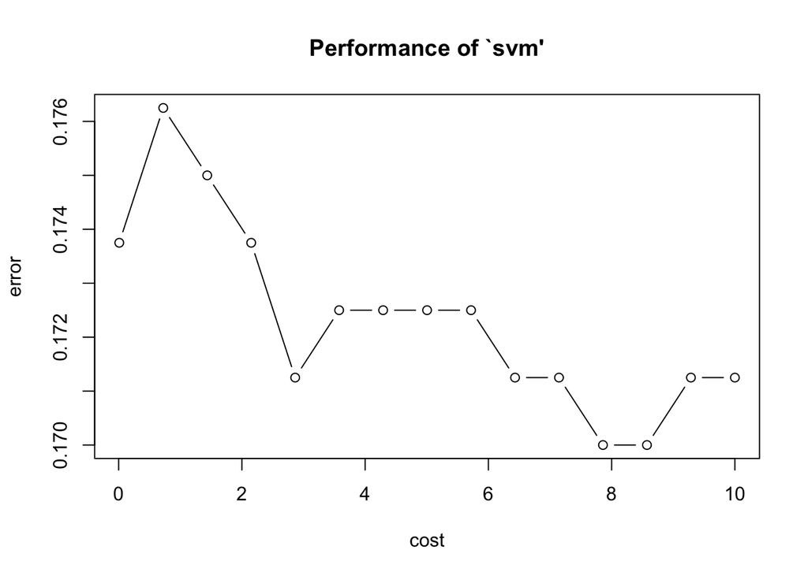

```r
cost_seq <- seq(0.01, 10, length.out = 15)

tune_svm <- function(kernel, ranges) {
  tune_out <- tune(
    svm,
    Purchase ~ .,
    data = train,
    kernel = kernel,
    ranges = ranges
  )

  plot(tune_out)

  res <- list(
    model_opt = tune_out$best.model,
    model_params = tune_out$best.parameters
  )

  return(res)
}

svc_opt <- tune_svm(
  "linear",
  ranges = list(cost = cost_seq)
)
```

## Part (e)

Compute the training and test error rates using this new value for `cost`.

```r
svc_opt_err <- svm_err(svc_opt$model_opt)

df_methods[2, ] <- c("SVC tuned", svc_opt_err)
```

## Part (f)

Repeat parts (b) through (c) using a support vector machine with a radial kernel. Use the default value for `gamma`.

```r
svm_radial <- svm(Purchase ~ ., data = train, kernel = "radial", cost = 0.01)

summary(svm_radial)
```

```
##
## Call:
## svm(formula = Purchase ~ ., data = train, kernel = "radial", cost = 0.01)
##
##
## Parameters:
##    SVM-Type:  C-classification
##  SVM-Kernel:  radial
##        cost:  0.01
##
## Number of Support Vectors:  634
##
##  ( 319 315 )
##
##
## Number of Classes:  2
##
## Levels:
##  CH MM
```

```r
svm_radial_err <- svm_err(svm_radial)
df_methods[3, ] <- c("SVM Radial", svm_radial_err)
```

Tune it

```r
svm_radial_tune <- tune_svm("radial", list(cost = cost_seq))
```

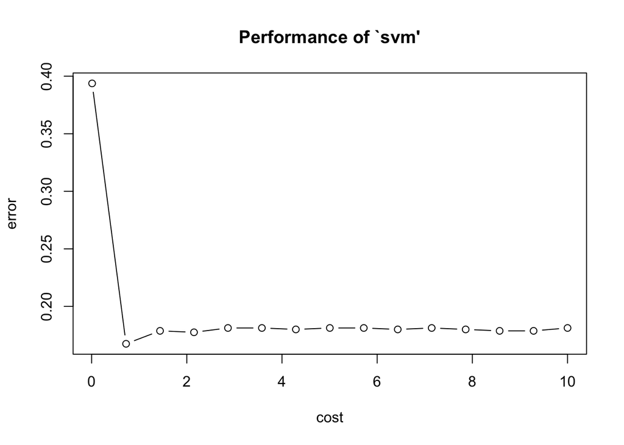

Performance for tuned model

```r
svm_radial_opt_err <- svm_err(svm_radial_tune$model_opt)

df_methods[4, ] <- c("SVM Radial Tuned", svm_radial_opt_err)
```

## Part (g)

Repeat parts (b) through (e) using a support vector machine with a polynomial kernel. Set `degree = 2`.

```r
svm_poly <- svm(Purchase ~ ., data = train, cost = 0.01, kernel = "polynomial",
                degree = 2)

summary(svm_poly)
```

```
##
## Call:
## svm(formula = Purchase ~ ., data = train, cost = 0.01, kernel = "polynomial", degree = 2)
##
##
## Parameters:
##    SVM-Type:  C-classification
##  SVM-Kernel:  polynomial
##        cost:  0.01
##      degree:  2
##      coef.0:  0
##
## Number of Support Vectors:  636
##
##  ( 321 315 )
##
##
## Number of Classes:  2
##
## Levels:
##  CH MM
```

```r
svm_poly_err <- svm_err(svm_poly)

df_methods[5, ] <- c("SVM Polynomial", svm_poly_err)
```

Tune it

```r
svm_poly_opt <- tune_svm("polynomial", cost_seq)
```

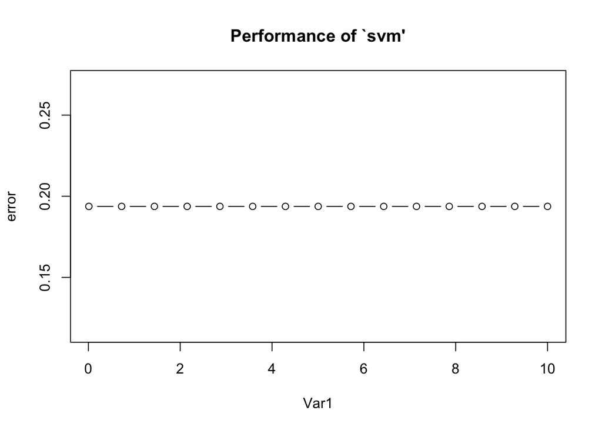

```r
svm_poly_opt_err <- svm_err(svm_poly_opt$model_opt)

df_methods[6, ] <- c("SVM Polynomial Tuned", svm_poly_opt_err)
```

## Part (h)

Overall, which approach sems to give the best results on this data?

```r
df_methods[order(df_methods$test_err), ]
```

```
##                 method train_err  test_err
## 2            SVC tuned   0.16375 0.1518519
## 1                  SVC   0.17500 0.1777778
## 4     SVM Radial Tuned   0.15125 0.1851852
## 6 SVM Polynomial Tuned   0.15375 0.2222222
## 5       SVM Polynomial   0.37250 0.3666667
## 3           SVM Radial   0.39375 0.3777778
```